# *Supplementary Information for:* Thermotolerant coral symbionts modulate heat stress-responsive genes in their hosts

Ross Cunning, Andrew C. Baker

# Figure S1

Figure S1. The proportion of *Durusdinium* symbionts in control (unmanipulated) and manipulated (bleached and recovered) corals for genets (n=6) that did not shuffle their symbionts (left panel; 1 ramet per genet per treatment), and genets (n=3) that did shuffle their symbionts (right panel; 6 ramets per genet per treatment).

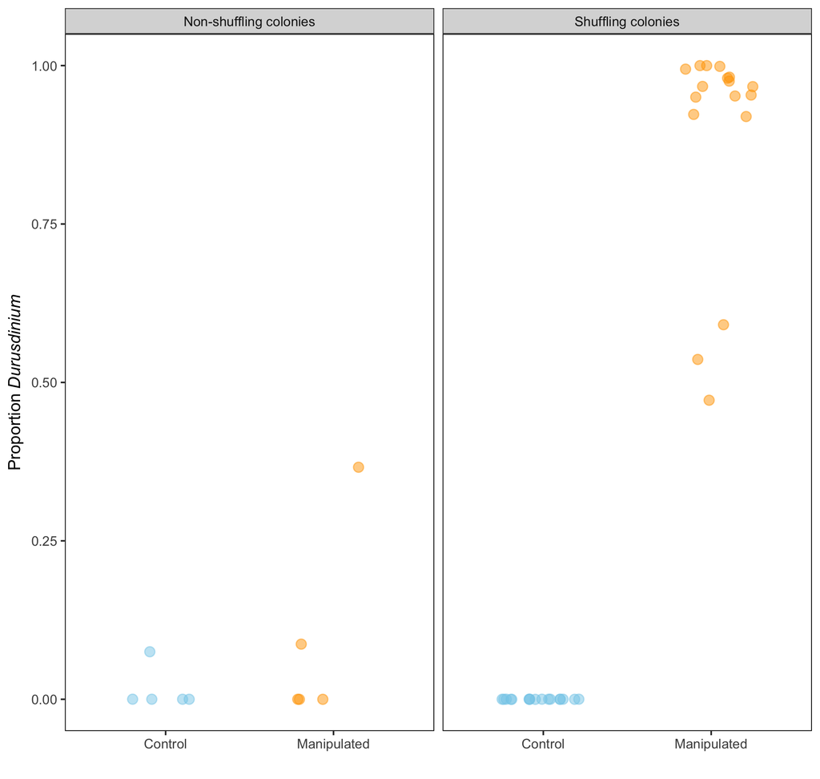

# Figure S2

Figure S2. Eukaryotic orthologous group (KOG) analysis identified functional categories that were up- or down-regulated (indicated by color) in corals with *Durusdinium* at 26°C vs. corals with *Cladocopium* at 26°C. Columns show KOG categories for each coral genet individually, and when all genets are analyzed together (right-hand column). Asterisks indicate a statistically significant difference (. = p < 0.1, * = p < 0.05, ** = p < 0.01, *** = p < 0.001).

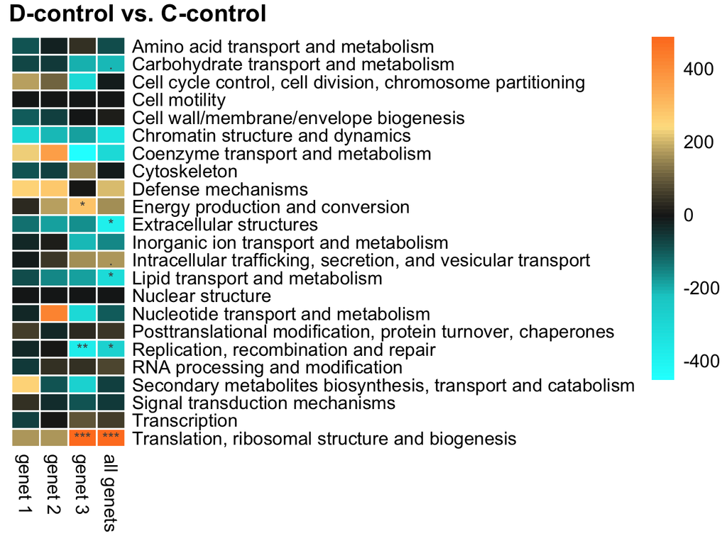

# Figure S3

Figure S3. Eukaryotic orthologous group (KOG) analysis identified functional categories that were up- or down-regulated (indicated by color) in corals with *Cladocopioum* at 32°C vs. corals with *Cladocopium* at 26°C. Columns show KOG categories for each coral genet individually, and when all genets are analyzed together (right-hand column). Asterisks indicate a statistically significant difference (. = p < 0.1, * = p < 0.05, ** = p < 0.01, *** = p < 0.001).

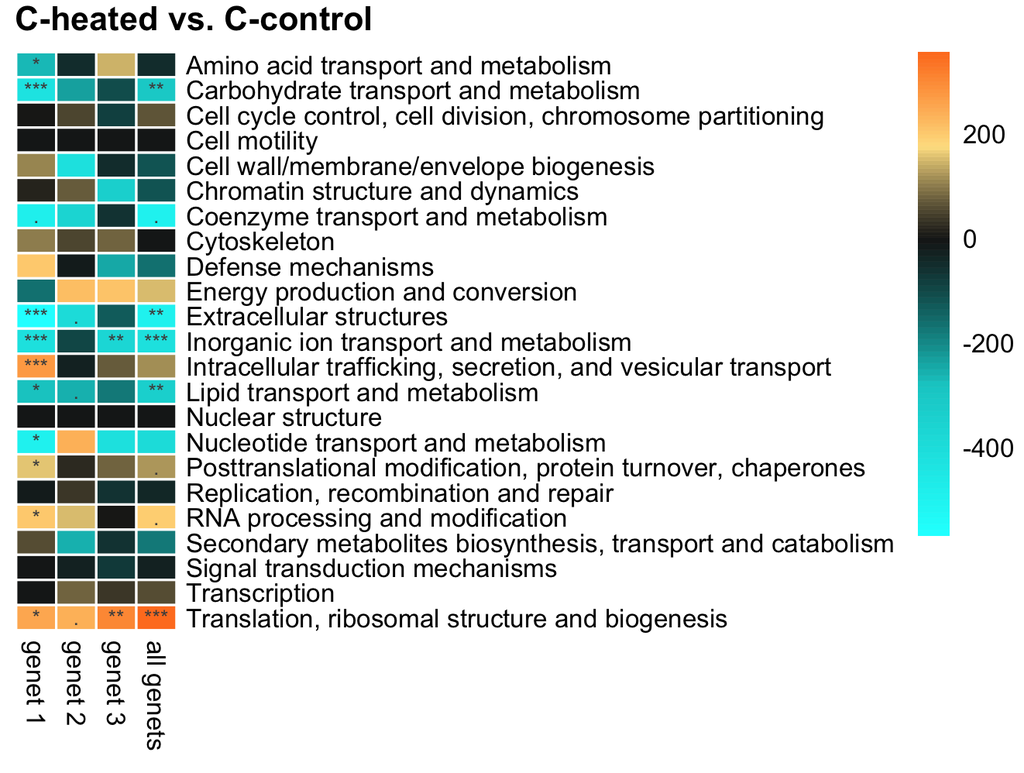

# Figure S4

Figure S4. Eukaryotic orthologous group (KOG) analysis identified functional categories that were up- or down-regulated (indicated by color) in corals with *Durusdinium* at 32°C vs. corals with *Durusdinium* at 26°C. Columns show KOG categories for each coral genet individually, and when all genets are analyzed together (right-hand column). Asterisks indicate a statistically significant difference (. = p < 0.1, * = p < 0.05, ** = p < 0.01, *** = p < 0.001).

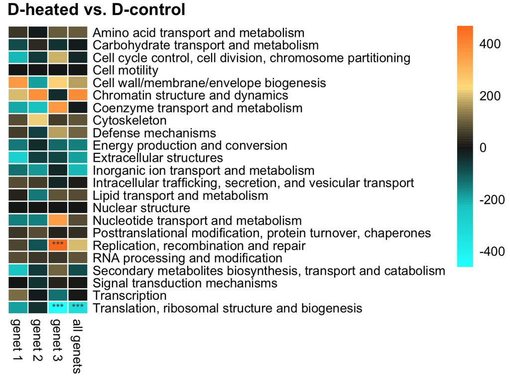

# Figure S5

Figure S5. Eukaryotic orthologous group (KOG) analysis identified functional categories that were up- or down-regulated (indicated by color) in corals with *Durusdinium* at 32°C vs. corals with *Cladocopium* at 32°C. Columns show KOG categories for each coral genet individually, and when all genets are analyzed together (right-hand column). Asterisks indicate a statistically significant difference (. = p < 0.1, * = p < 0.05, ** = p < 0.01, *** = p < 0.001).

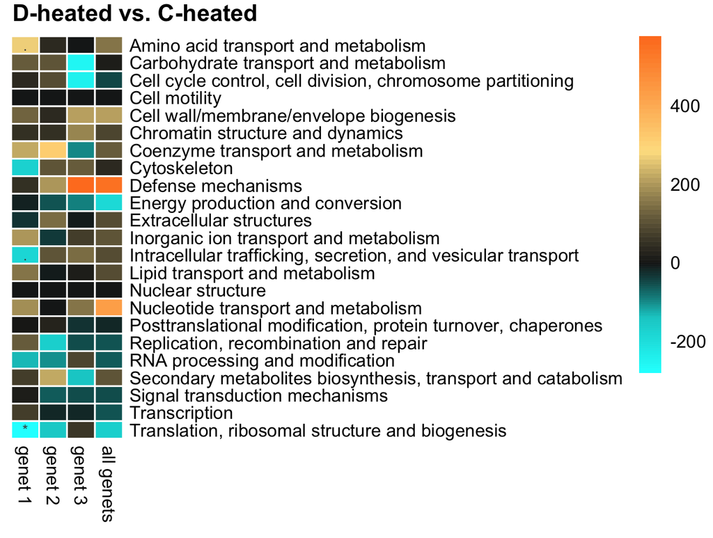

# Table S1

Table S1. All gene ontology (GO) terms identified by GO_MWU that were significantly different across all experimental contrasts (adjusted p-value < 0.01). Cheat = corals with *Cladocopium* at 32°C, Cctrl = corals with *Cladocopium* at 26°C, Dheat = corals with *Durusdinium* at 32°C, Dctrl = corals with *Durusdinium* at 26°C. BP = ‘biological process’, CC = ‘cellular component’, MF = ‘molecular function’.

| contrast | ontology | delta.rank | name | p.adj |
| --- | --- | --- | --- | --- |
| Cheat.Cctrl | BP | -432 | anion transport | 0.0039258 |
| Cheat.Cctrl | BP | -622 | sodium ion transport | 0.0094110 |
| Cheat.Cctrl | BP | -713 | ammonium transport | 0.0094110 |
| Cheat.Cctrl | BP | 440 | protein localization to membrane | 0.0017478 |
| Cheat.Cctrl | BP | 475 | protein targeting to membrane | 0.0026238 |
| Cheat.Cctrl | BP | 273 | positive regulation of catalytic activity | 0.0039045 |
| Cheat.Cctrl | BP | 490 | protein-containing complex disassembly | 0.0045161 |
| Cheat.Cctrl | BP | 256 | mRNA metabolic process | 0.0062611 |
| Cheat.Cctrl | BP | 238 | intracellular signal transduction | 0.0067086 |
| Cheat.Cctrl | BP | 274 | regulation of transferase activity | 0.0081854 |
| Cheat.Cctrl | CC | 494 | cytosolic ribosome | 0.0001344 |
| Cheat.Cctrl | CC | 392 | cytosolic part | 0.0004238 |
| Cheat.Cctrl | CC | 226 | ribonucleoprotein complex | 0.0009429 |
| Cheat.Cctrl | CC | 353 | ribosome | 0.0024924 |
| Cheat.Cctrl | MF | -519 | secondary active transmembrane transporter activity | 0.0007211 |
| Cheat.Cctrl | MF | -427 | anion transmembrane transporter activity | 0.0012722 |
| Cheat.Cctrl | MF | -442 | organic anion transmembrane transporter activity | 0.0043506 |
| Cheat.Cctrl | MF | -506 | sodium ion transmembrane transporter activity | 0.0091040 |
| Cheat.Cctrl | MF | 422 | structural constituent of ribosome | 0.0007211 |
| Cheat.Cctrl | MF | 232 | RNA binding | 0.0012722 |
| Dctrl.Cctrl | BP | 660 | translational initiation | 0.0000004 |
| Dctrl.Cctrl | BP | 670 | protein-containing complex disassembly | 0.0000014 |
| Dctrl.Cctrl | BP | 696 | spindle elongation | 0.0000150 |
| Dctrl.Cctrl | BP | 486 | protein targeting to membrane | 0.0007407 |
| Dctrl.Cctrl | BP | 428 | cellular component disassembly | 0.0009385 |
| Dctrl.Cctrl | BP | 464 | translational elongation | 0.0010874 |
| Dctrl.Cctrl | BP | 393 | protein localization to membrane | 0.0035124 |
| Dctrl.Cctrl | BP | 420 | RNA catabolic process | 0.0048821 |
| Dctrl.Cctrl | BP | 254 | mRNA metabolic process | 0.0048821 |
| Dctrl.Cctrl | CC | 622 | cytosolic ribosome | 0.0000001 |
| Dctrl.Cctrl | CC | 425 | ribosome | 0.0000463 |
| Dctrl.Cctrl | CC | 425 | cytosolic part | 0.0000463 |
| Dctrl.Cctrl | CC | 468 | large ribosomal subunit | 0.0022966 |
| Dctrl.Cctrl | CC | 677 | cytosolic small ribosomal subunit | 0.0022966 |
| Dctrl.Cctrl | MF | 487 | structural constituent of ribosome | 0.0000155 |
| Dheat.Dctrl | BP | -544 | translational initiation | 0.0003707 |
| Dheat.Dctrl | CC | -420 | cytosolic ribosome | 0.0061805 |
| Dheat.Dctrl | MF | -396 | structural constituent of ribosome | 0.0024580 |
| Dheat.Dctrl | MF | -472 | organic anion transmembrane transporter activity | 0.0024580 |
| Dheat.Dctrl | MF | 515 | molecular adaptor activity | 0.0024580 |
| Dheat.Dctrl | MF | 647 | signaling adaptor activity | 0.0026139 |

# Figure S6

Figure S6. The number of differentially expressed genes (DEGs) detected between randomized groupings (n=126 permutations) of 5 Wilkie corals vs. 4 Wilkie corals, using the dataset of Barfield et al. 2018. The actual comparison of the 5 corals with clade C vs. the 4 corals with clade D is shown in red, while all randomized comparisons of 5 vs. 4 corals are shown in green. A p-value of 0.022 is used as a cutoff for DEGs since this is the empirical 10% FDR value calculated and used by Barfield et al. for this particular dataset. Code to reproduce this analysis and figure is available here.

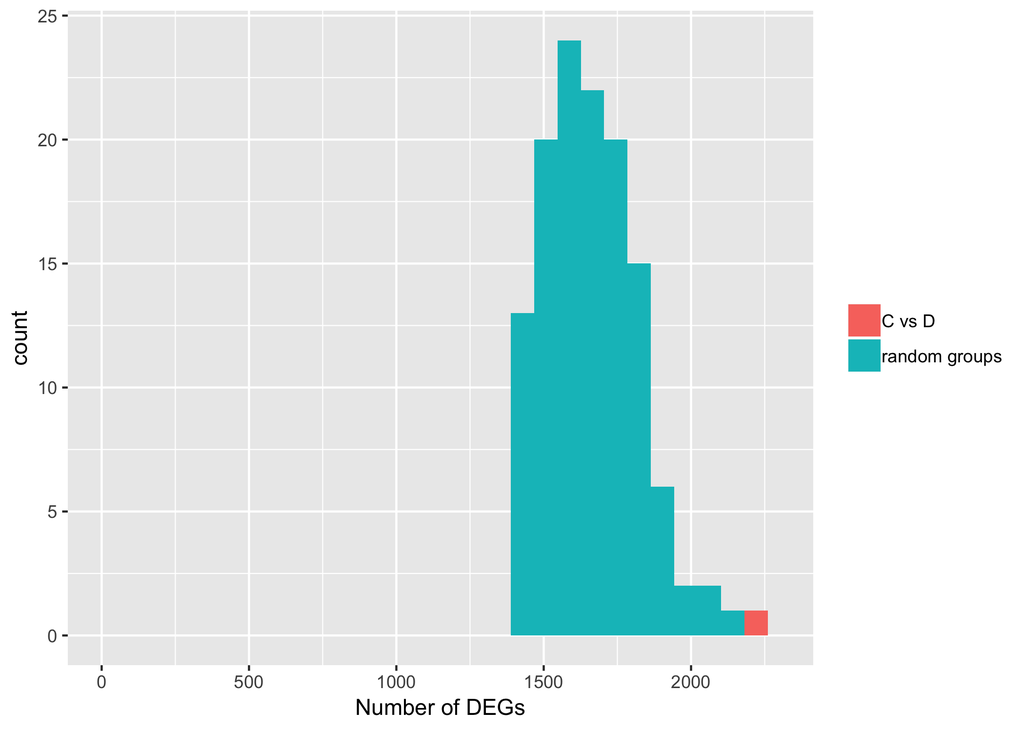